# Exploratory Data Analysis Project

### Categorical Variables

First, let’s take a look on various categorical variables starting with Term.

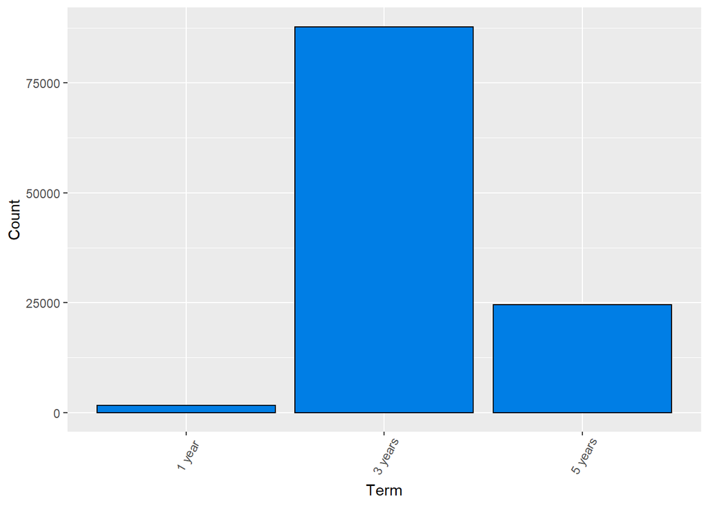

```
##
##     1 year    3 years    5 years
## 0.01416572 0.77040821 0.21542607
```

> Above 90% of the loans in this dataset are with term more than 1 year. Most of them is of 3 years.

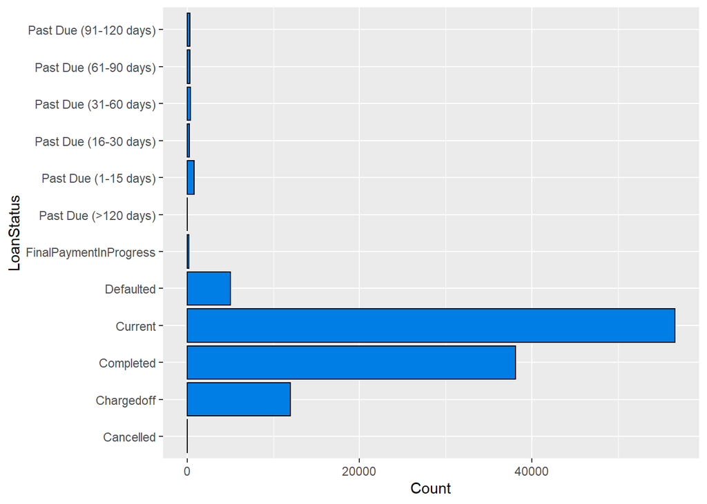

```
##
##              Cancelled             Chargedoff              Completed
##           0.0000438839           0.1052511476           0.3341671274
##                Current              Defaulted FinalPaymentInProgress
##           0.4965551138           0.0440418828           0.0017992399
##   Past Due (>120 days)   Past Due (1-15 days)  Past Due (16-30 days)
##           0.0001404285           0.0070740848           0.0023258467
##  Past Due (31-60 days)  Past Due (61-90 days) Past Due (91-120 days)
##           0.0031859712           0.0027471322           0.0026681412
```

> There are four major loan status: “Defaulted”, “Current”, “Completed”, and “Chargedoff.”

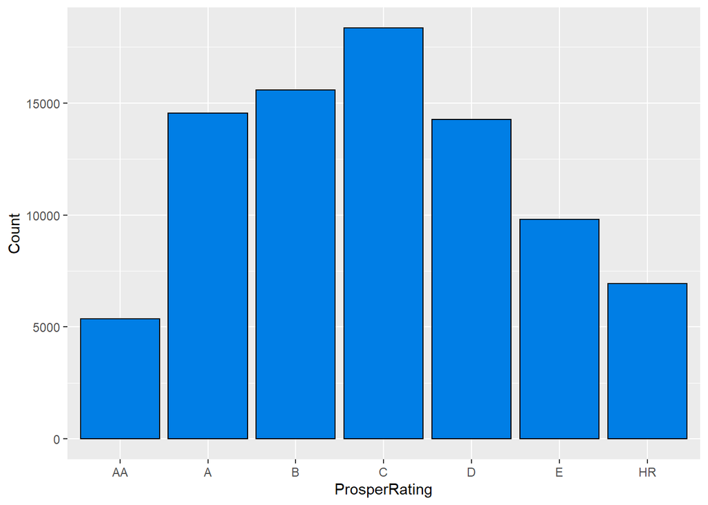

```
##
##         AA          A          B          C          D          E         HR
## 0.06330949 0.17148480 0.18362344 0.21619742 0.16822033 0.11543493 0.08172958
##         NA
## 0.00000000
```

> The above bar chart shows Prosper’s rating distribution. The unrated loans are removed in this plot.

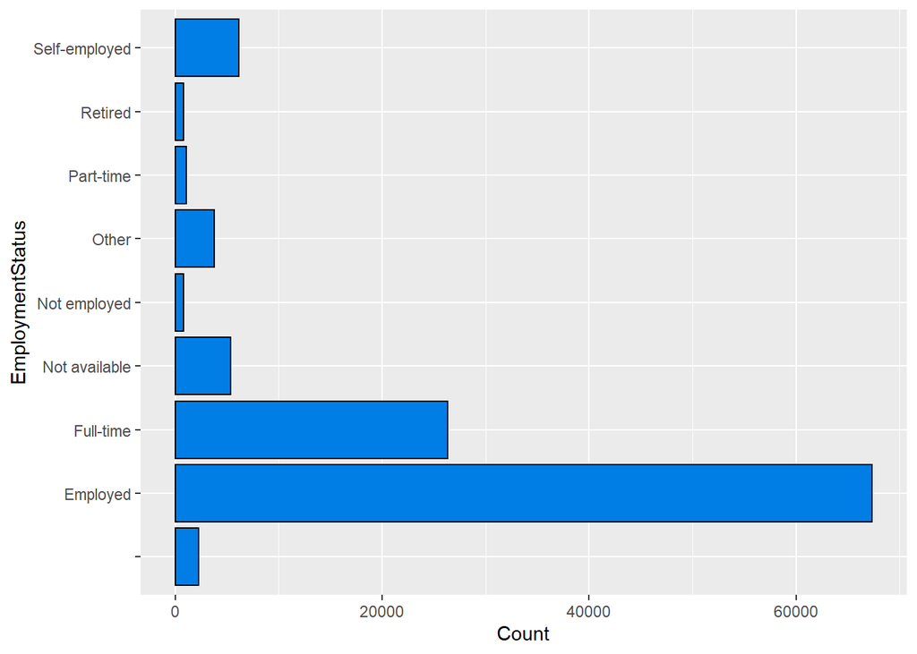

```
##
##                    Employed     Full-time Not available  Not employed
##   0.019791639   0.590870393   0.231312041   0.046929443   0.007328611
##         Other     Part-time       Retired Self-employed
##   0.033404425   0.009549137   0.006977540   0.053836769
```

> The majority of Prosper users are either employed or have a full-time job.

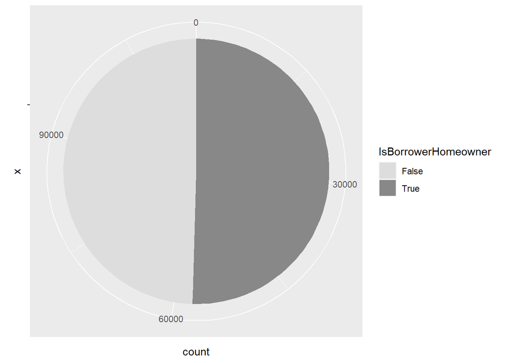

> About half of the users are homeowners.

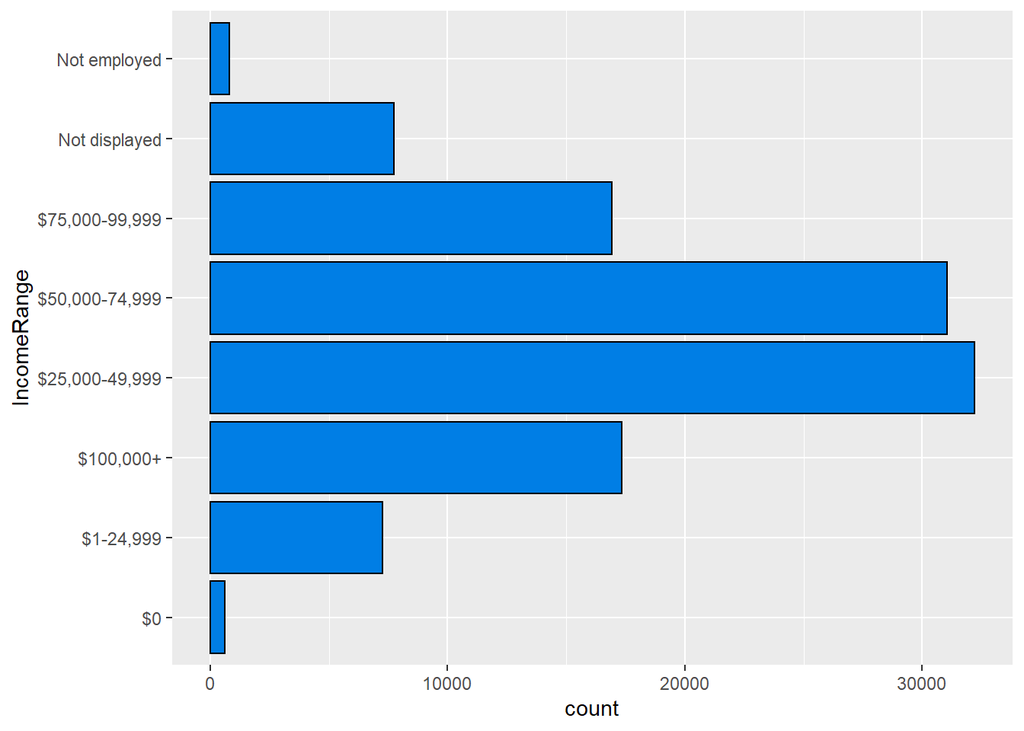

```
##
##             $0      $1-24,999      $100,000+ $25,000-49,999 $50,000-74,999
##    0.005450380    0.063842299    0.152163037    0.282542107    0.272519024
## $75,000-99,999  Not displayed   Not employed
##    0.148468013    0.067941055    0.007074085
```

> About 70% of borrowers’ income are in the range of $25,000 - $100,000

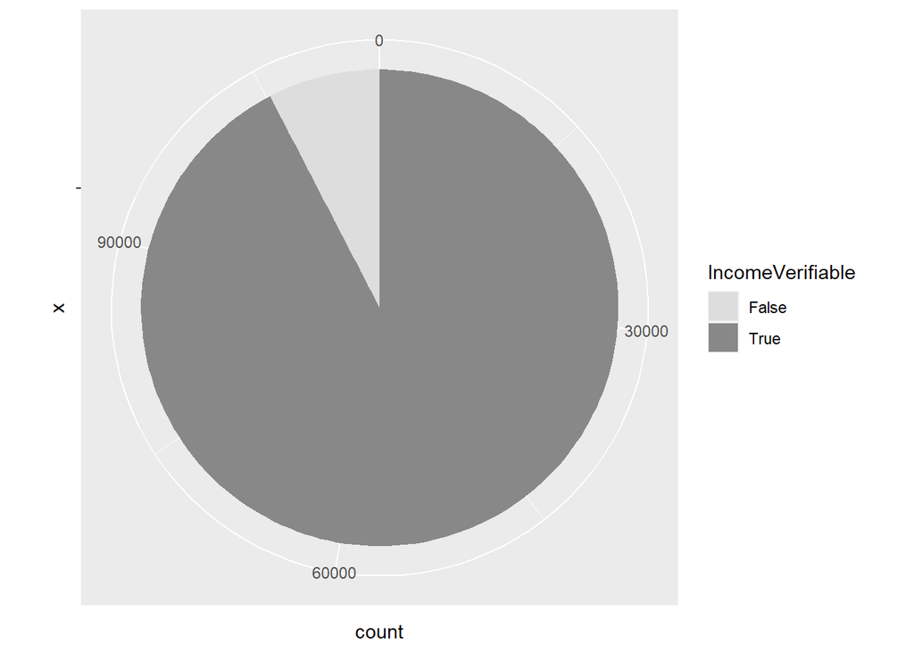

> Most of borrowers have their income verified.

#### Numerical Variables

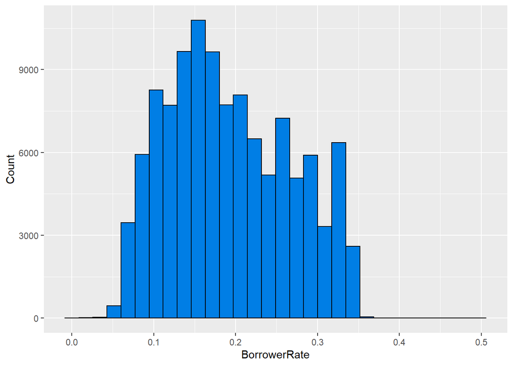

```
##    Min. 1st Qu.  Median    Mean 3rd Qu.    Max.
##  0.0000  0.1340  0.1840  0.1928  0.2500  0.4975
```

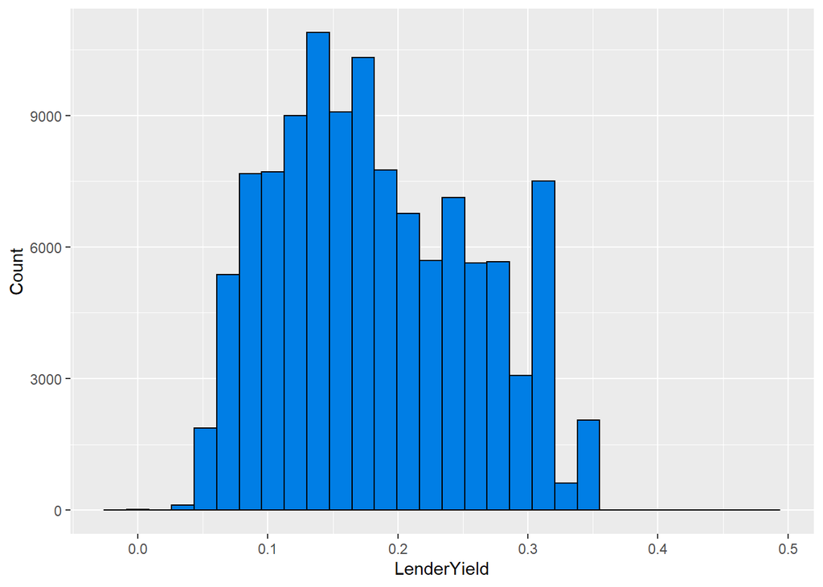

```
##    Min. 1st Qu.  Median    Mean 3rd Qu.    Max.
## -0.0100  0.1242  0.1730  0.1827  0.2400  0.4925
```

> The BorrowerRate has a right-skewed distribution, with a mean of 19.28%, and median of 18.40%. Similarly, the LenderYield also has a right-skewed distribution, with a mean of 18.27%, and median of 17.30%.

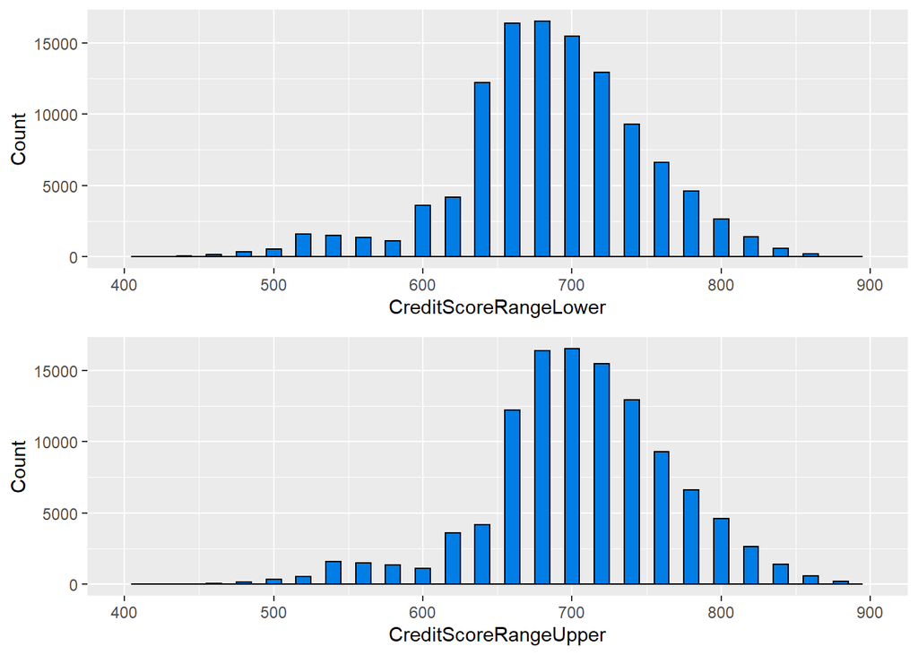

> The ranges of credit scores are small compared to the distributions. I will use lower credit score for further analyses.

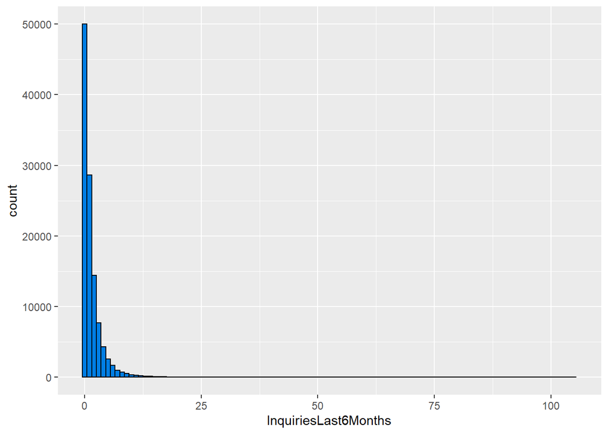

```
##  [1]   3   0   1   7   2   5   4  11   6   9  44  NA   8  12  19  42  27  10  15
## [20]  13  21  17  38  16  14  18  22  25  28  20  23  26  29  24  40  41  30  33
## [39]  31  32  34  35  36  63  97  37  46  52 105  53  50
```

> The distribution of InquiriesLast6Months is right-skewed and long-tailed. Outliers like 105 and 53 exist.

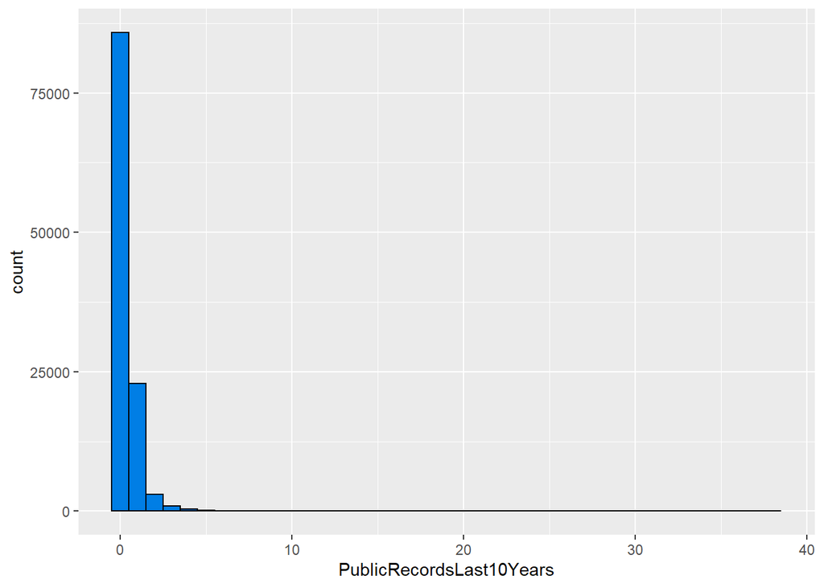

```
##  [1]  0  1  2  5 NA  3  4  7  6 11  8 12  9 10 15 21 13 25 38 14 16 30 20 34 22
## [26] 17
```

> The distribution of PublicRecordsLast10Years is right-skewed and has some outliers.

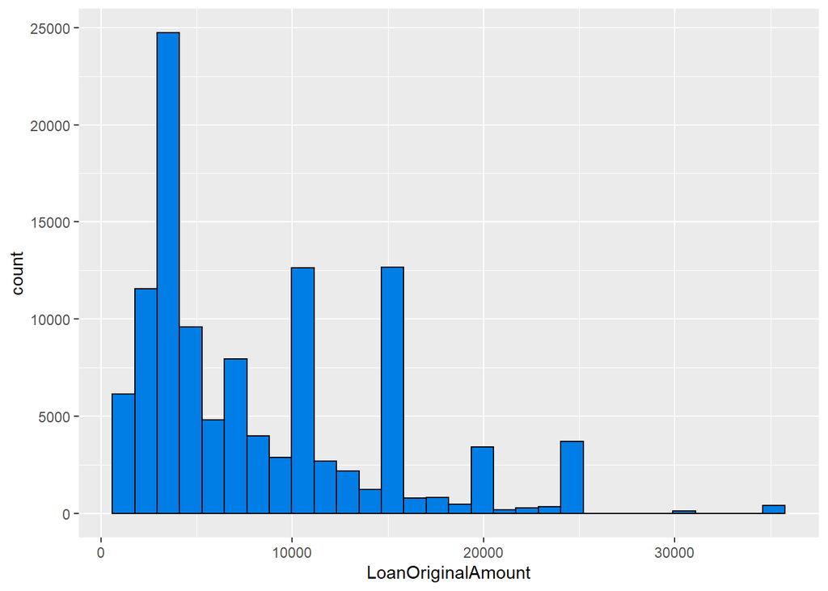

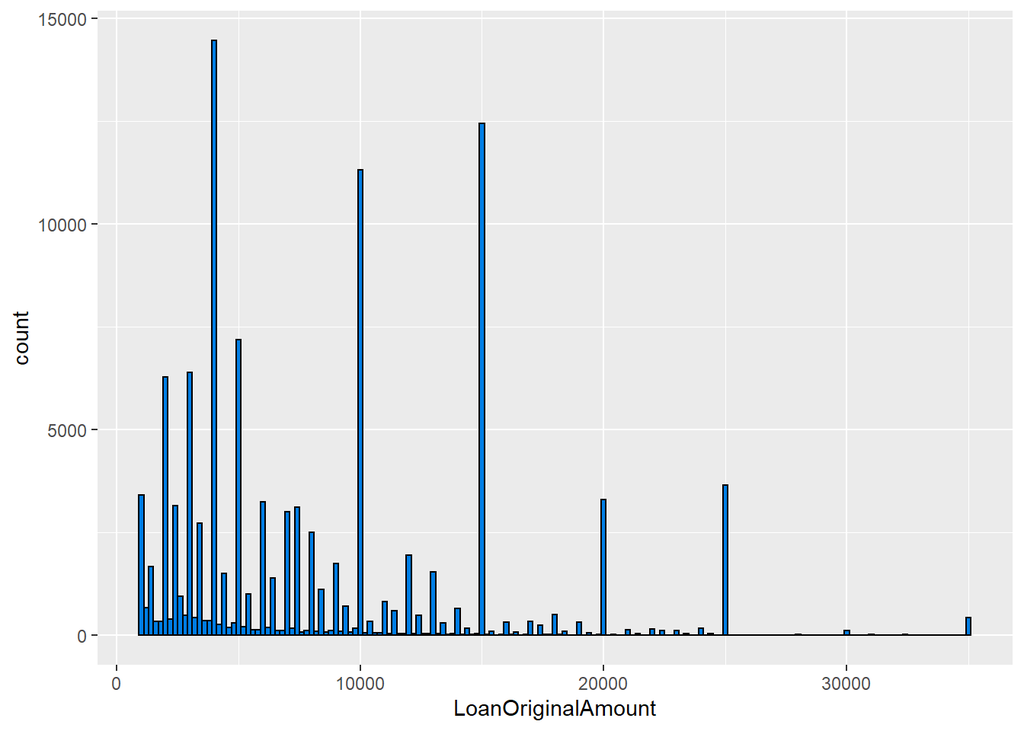

> LoanOriginalAmount also displays a long-tailed distribution, with some numbers especially higher. The reason why these numbers are more frequent might be because they are the exact numbers (eg. 10,000, 15,000, 20,000) that people tend to choose.